'Sample 3 - Read data from a file.ipynb' 8/27/19 D. Candela

# Sample notebook 3: Reading data from a file

This builds on **Sample notebook 2: Plotting error bars and plotting functions.**

If you use a text editor like Notepad to look at the file `data0.txt` you will see:

```
  0.000000   3.927996
  0.500000   3.787147
  1.000000   3.811854
  1.500000   3.176016
  2.000000   3.091018
  2.500000   2.603980
      .          .
      .          .
      .          .
```

These are the $x$ and $y$ values from some imaginary experiment, written in a simple format with each $x$ and $y$ on a line with spaces or tabs between them.

**To read in data like these, we use `np.loadtxt` which puts the data in a two-dimensional array.** We can slice out the $x$ and $y$ columns of the array and plot them:

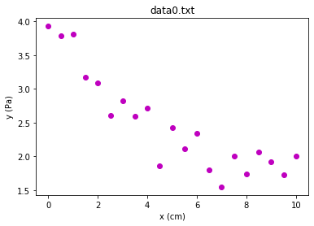

```python
import matplotlib.pyplot as plt
%matplotlib inline
import numpy as np

# Read in the data (the file data0.txt should be in
# the same folder as this Jupyter Notebook)
darray = np.loadtxt('data0.txt')

# Slice out the x and y columns
xs = darray[:,0]
ys = darray[:,1]

# Plot the data
plt.plot(xs,ys,'mo')
plt.xlabel('x (cm)')
plt.ylabel('y (Pa)')
plt.title('data0.txt')
plt.show()
```

The command `xs = darray[:,0]` sets `xs` to be the first column the data, and `ys = darray[:,1]` sets `ys` to be the second column -- just what we need here.

(In case you are interested: When used as an array index in Python, `:` means 'all'. Therefore `darray[:,0]` means the elements of `darray` from all rows and the first (zeroth) column.)

### Data in csv format or with header rows

Many applications including Excel typically write out **csv** files, which have commas rather than spaces between the numbers. A csv file can be read by adding the `delimiter=','` option to `np.loadtxt`, as follows:

```
darray = np.loadtxt('data0.txt',delimiter=',')
```

Similarly, a data file that has one or more **header rows** before the rows containing data can most easily be read by simply skipping over the header rows. This is done using the `skiprows` option, as follows:

```
darray = np.loadtxt('data0.txt',skiprows=2)
```

This command would read `data0.txt` into `darray`, skipping over the first two rows in the file.

### Data with only $y$-values

For some types of experiment the data file might contain only a single column of $y$-values, for example if the data is taken at known, regular time intervals but the times are not recorded with the data. The file datay.txt looks like this, with a single column of numbers:

```
  2.829065
  3.087545
  3.172547
  3.221837
  3.276875
  3.071362
  3.125674
      .
      .
      .
```

Because the file has only one column, `np.loadtxt` directly gives the array of $y$-values -- no slicing required.

To find the number of data points $N$, the `len` (length) function is used on the array of $y$-values.

Then we use `np.linspace` to create an array of $N$ equally-spaced times from $t=0$ to $t = (N-1)\Delta t$ where $\Delta t$ is the time interval between points:

```
File had 100 points.
```

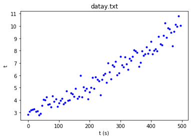

```python
# Read in the one-column data file
yvals = np.loadtxt('datay.txt')

# Find the number of y points and print it out
nn = len(yvals)
print(f'File had {nn} points.')

# Make array of times
deltat = 5.0   # enter time between points (s) here
tvals = np.linspace(0,(nn-1)*deltat,nn)

# Make the plot
plt.plot(tvals,yvals,'b.')
plt.title('datay.txt')
plt.xlabel('t (s)')
plt.ylabel('t')
plt.show()
```

### Reading data with error bars

The file "data1.txt" looks like this:

```
    x (cm)     y (mV)       yerr
  0.000000   3.927996   0.200000
  0.500000   3.787147   0.200000
  1.000000   3.811854   0.200000
  1.500000   3.176016   0.200000
     .          .          .
     .          .          .
     .          .          .
```

This represents the same imaginary experiment used at the beginning of this notebook, except now there is a third column containing separate uncertainties for each data point.

We can read the file using `np.loadtxt`, slice it into its three separate columns, and use `plt.errorbar` to plot the data with error bars:

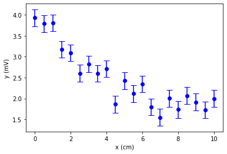

```python
# Read the data from file
data = np.loadtxt('data1.txt', float,skiprows=1)

# Slice into three 1D arrays
x = data[:,0]
y = data[:,1]
yerr = data[:,2]

# Plot the data with error bars:
plt.errorbar(x,y,yerr,fmt='bo',capsize=5)
plt.xlabel('x (cm)')
plt.ylabel('y (mV)')
plt.show()
```